# Logistic Regression hw

```r
library(tidyverse)
library(janitor)
```

```r
juice <- read_csv("data/orange_juice.csv") %>%
  clean_names() %>%
  mutate(
    special_ch = ifelse(special_ch == 1, TRUE, FALSE),
    special_mm = ifelse(special_mm == 1, TRUE, FALSE),
    store7 = as.factor(store7),
    weekof_purchase = as.factor(weekof_purchase),
    store_id = as.factor(store_id),
    purchase_mm = ifelse(purchase == "MM", TRUE, FALSE),
    ) %>%
  select(-c(purchase, store, store7)) # I chose to remove these variable right away as they are already represented in the dataset in other columns.
juice
```

| weekof_purchase | store_id | price_ch | price_mm | disc_ch | disc_mm | special_ch | special_mm | loyal_ch | sale_price_mm | sale_price_ch | price_diff | pct_disc_mm | pct_disc_ch | list_price_diff | purchase_mm |
| --- | --- | --- | --- | --- | --- | --- | --- | --- | --- | --- | --- | --- | --- | --- | --- |
| 237 | 1 | 1.75 | 1.99 | 0.00 | 0.00 | FALSE | FALSE | 0.500000 | 1.99 | 1.75 | 0.24 | 0.000000 | 0.000000 | 0.24 | FALSE |
| 239 | 1 | 1.75 | 1.99 | 0.00 | 0.30 | FALSE | TRUE | 0.600000 | 1.69 | 1.75 | -0.06 | 0.150754 | 0.000000 | 0.24 | FALSE |
| 245 | 1 | 1.86 | 2.09 | 0.17 | 0.00 | FALSE | FALSE | 0.680000 | 2.09 | 1.69 | 0.40 | 0.000000 | 0.091398 | 0.23 | FALSE |
| 227 | 1 | 1.69 | 1.69 | 0.00 | 0.00 | FALSE | FALSE | 0.400000 | 1.69 | 1.69 | 0.00 | 0.000000 | 0.000000 | 0.00 | TRUE |
| 228 | 7 | 1.69 | 1.69 | 0.00 | 0.00 | FALSE | FALSE | 0.956535 | 1.69 | 1.69 | 0.00 | 0.000000 | 0.000000 | 0.00 | FALSE |
| 230 | 7 | 1.69 | 1.99 | 0.00 | 0.00 | FALSE | TRUE | 0.965228 | 1.99 | 1.69 | 0.30 | 0.000000 | 0.000000 | 0.30 | FALSE |
| 232 | 7 | 1.69 | 1.99 | 0.00 | 0.40 | TRUE | TRUE | 0.972182 | 1.59 | 1.69 | -0.10 | 0.201005 | 0.000000 | 0.30 | FALSE |
| 234 | 7 | 1.75 | 1.99 | 0.00 | 0.40 | TRUE | FALSE | 0.977746 | 1.59 | 1.75 | -0.16 | 0.201005 | 0.000000 | 0.24 | FALSE |
| 235 | 7 | 1.75 | 1.99 | 0.00 | 0.40 | FALSE | FALSE | 0.982197 | 1.59 | 1.75 | -0.16 | 0.201005 | 0.000000 | 0.24 | FALSE |
| 238 | 7 | 1.75 | 1.99 | 0.00 | 0.40 | FALSE | FALSE | 0.985757 | 1.59 | 1.75 | -0.16 | 0.201005 | 0.000000 | 0.24 | FALSE |

[output cut: 990 more lines]

```r
summary(juice)
```

```
 weekof_purchase store_id    price_ch        price_mm        disc_ch
 274    : 39     1:157    Min.   :1.690   Min.   :1.690   Min.   :0.00000
 275    : 33     2:222    1st Qu.:1.790   1st Qu.:1.990   1st Qu.:0.00000
 269    : 32     3:196    Median :1.860   Median :2.090   Median :0.00000
 259    : 31     4:139    Mean   :1.867   Mean   :2.085   Mean   :0.05186
 260    : 29     7:356    3rd Qu.:1.990   3rd Qu.:2.180   3rd Qu.:0.00000
 233    : 28              Max.   :2.090   Max.   :2.290   Max.   :0.50000
 (Other):878
    disc_mm       special_ch      special_mm         loyal_ch        sale_price_mm
 Min.   :0.0000   Mode :logical   Mode :logical   Min.   :0.000011   Min.   :1.190
 1st Qu.:0.0000   FALSE:912       FALSE:897       1st Qu.:0.325257   1st Qu.:1.690
 Median :0.0000   TRUE :158       TRUE :173       Median :0.600000   Median :2.090
 Mean   :0.1234                                   Mean   :0.565782   Mean   :1.962
 3rd Qu.:0.2300                                   3rd Qu.:0.850873   3rd Qu.:2.130
 Max.   :0.8000                                   Max.   :0.999947   Max.   :2.290

 sale_price_ch     price_diff       pct_disc_mm      pct_disc_ch      list_price_diff
 Min.   :1.390   Min.   :-0.6700   Min.   :0.0000   Min.   :0.00000   Min.   :0.000
 1st Qu.:1.750   1st Qu.: 0.0000   1st Qu.:0.0000   1st Qu.:0.00000   1st Qu.:0.140
 Median :1.860   Median : 0.2300   Median :0.0000   Median :0.00000   Median :0.240
 Mean   :1.816   Mean   : 0.1465   Mean   :0.0593   Mean   :0.02731   Mean   :0.218
 3rd Qu.:1.890   3rd Qu.: 0.3200   3rd Qu.:0.1127   3rd Qu.:0.00000   3rd Qu.:0.300
 Max.   :2.090   Max.   : 0.6400   Max.   :0.4020   Max.   :0.25269   Max.   :0.440

 purchase_mm
 Mode :logical
 FALSE:653
 TRUE :417
```

```r
unique(juice$store)
```

[output not shown]

```r
library(GGally)
```

```r
pairs1 <- c("purchase_mm", "weekof_purchase", "store_id", "price_ch")
pairs2 <- c("purchase_mm", "price_mm", "disc_ch", "disc_mm")
pairs3 <- c("purchase_mm", "special_ch", "special_mm", "loyal_ch")
pairs4 <- c("purchase_mm", "sale_price_mm", "sale_price_ch", "price_diff")
pairs5 <- c("purchase_mm", "pct_disc_mm", "pct_disc_ch", "list_price_diff")
```

```
Extra arguments: 'report' are being ignored.  If these are meant to be aesthetics, submit them using the 'mapping' variable within ggpairs with ggplot2::aes or ggplot2::aes_string.
```

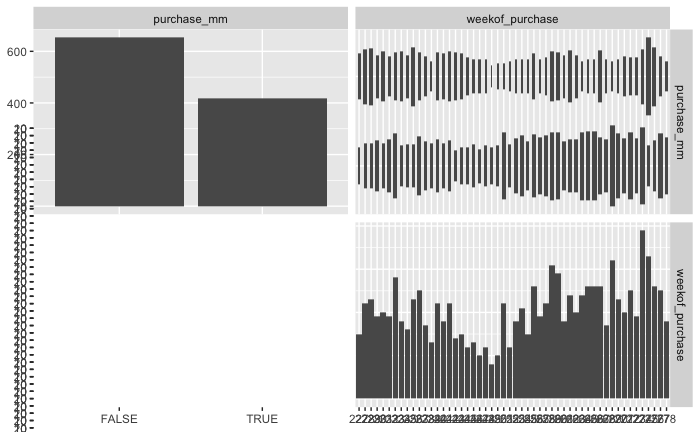

```r
juice %>%
  select(purchase_mm, weekof_purchase) %>%
  ggpairs(cardinality_threshold = 52, report = FALSE)
```

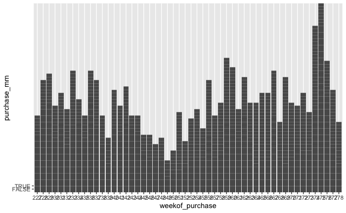

```r
juice %>%
ggplot(aes(x = weekof_purchase, y = purchase_mm)) +
  geom_col()
```

[output not shown]

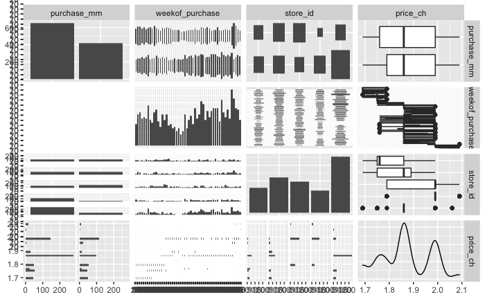

```r
#there seems to be quite a lot of variability in purchase_mm depending on weekof_purchase, therefore I will keep weekof_purchase variable.

juice %>%
  select(pairs1) %>%
  ggpairs(cardinality_threshold = 52, report = FALSE)
```

[output not shown]

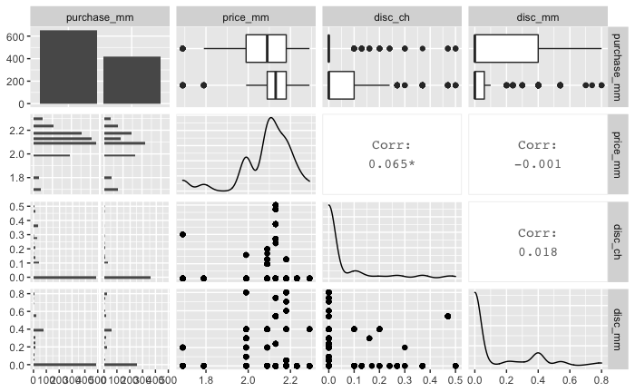

```r
#weekof_purchase, store_id

juice %>%
  select(pairs2) %>%
  ggpairs(report = FALSE)
```

[output not shown]

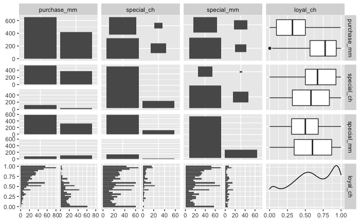

```r
#price_mm, disc_mm

juice %>%
  select(pairs3)%>%
  ggpairs(report = FALSE)
```

[output not shown]

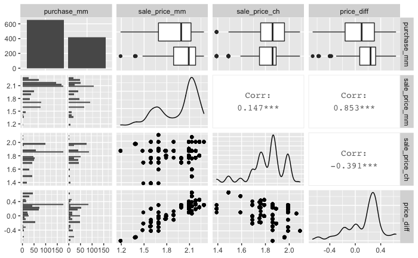

```r
#special_ch, special_mm, ?loyal_ch

juice %>%
  select(pairs4) %>%
  ggpairs(report = FALSE)
```

[output not shown]

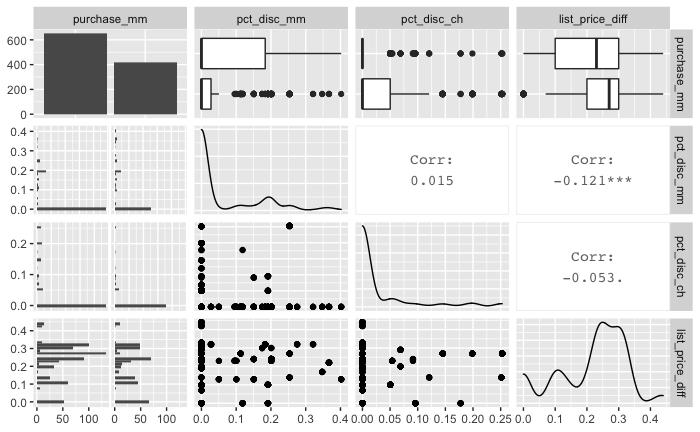

```r
#sale_price_ch, store7

juice %>%
  select(pairs5) %>%
  ggpairs(report = FALSE)
```

```r
#pct_disc_mm
```

I think, if I was building a model manually, I would use the following variables: weekof_purchase, store_id, price_mm, disc_mm, special_ch, special_mm, sale_price_ch, pct_disc_mm, loyal_ch.

But I am finding it hard to understand, so I will make an automated feature selection.

```r
#create training & testing datasets
n_data <- nrow(juice)
test_index <- sample(1:n_data, size = n_data*0.1)

test_juice <- slice(juice, test_index)
train_juice <- slice(juice, -test_index)
```

```r
library(modelr)
library(pROC)
```

```r
alias(all_feature_model)
```

[output not shown]

[output cut: 47 more lines]

```
                weekof_purchase276 weekof_purchase277 weekof_purchase278 store_id2
sale_price_mm    0                  0                  0                  0
sale_price_ch    0                  0                  0                  0
price_diff       0                  0                  0                  0
list_price_diff  0                  0                  0                  0
                store_id3 store_id4 store_id7 price_ch price_mm disc_ch disc_mm
sale_price_mm    0         0         0         0        1        0      -1
sale_price_ch    0         0         0         1        0       -1       0
price_diff       0         0         0        -1        1        1      -1
list_price_diff  0         0         0        -1        1        0       0
                special_chTRUE special_mmTRUE loyal_ch pct_disc_mm pct_disc_ch
sale_price_mm    0              0              0        0           0
sale_price_ch    0              0              0        0           0
price_diff       0              0              0        0           0
list_price_diff  0              0              0        0           0
```

```r
auc_manual_feature
```

```
Area under the curve: 0.9221
```

Automated model no interactions

```r
library(glmulti)
```

Best model has been identified as: purchase_mm ~ loyal_ch + price_diff

```r
auc_manual_feature
```

```
Area under the curve: 0.9014
```

Using training dataset, the model “purchase_mm ~ weekof_purchase + store_id + price_mm + disc_mm + special_ch + special_mm + sale_price_ch + pct_disc_mm + loyal_ch” had AUC of 0.9221.

The model “purchase_mm ~ loyal_ch + price_diff” has AUS of 0.9014.

```r
auc_manual_feature
```

```
Area under the curve: 0.8666
```

```r
auc_manual_feature
```

```
Area under the curve: 0.8666
```

Manual model AUC using test data was: 0.8666

*I have no idea :(*